# R Notebook

# Effects of False Positives on Inference for Linked Datasets

## Overview

Record linkage enables disparate patient level datasets to be combined and use for analysis. This is particularly useful for analyses which would be difficult or impossible to conduct through traditional data capture methods. Linkage is usually done on a variety of personally identifiable information (PII), such as name, date of birth, zip code, etc.

One potential problem relates to the methods which are used to link datasets. When false matches occur, you introduce noise into your data in a unique way. Quantifying the precision and recall of various linkage methods is vital to understanding the quality of data, and it is especially important in privacy preserving contexts where you are not able to look at the underlying PII to inspect potential errors.

Here we’ll demonstrate the effects of various precision levels in a basic linear regression setting.

## Example

### Population

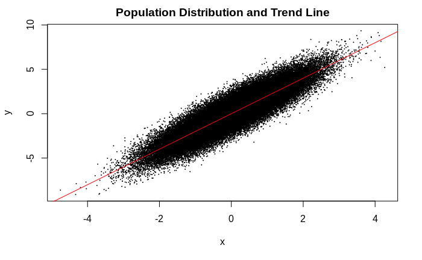

```r
plot(x = df$x, y = df$y, pch = 20, cex = .2, xlab = 'x', ylab = 'y', main = 'Population Distribution and Trend Line')
abline(b0, b1, col = 'red')
```

### Linked Sampling and Linear Example

Let’s say we have one dataset that contains a sample of the $y$ variables (weight), and a separate dataset that contains a sample of the $x$ variables (height), which we linked based on some privacy preserving ID.

Assume we link these datasets together to create a combined sample of 1000 records out of the population, and our linkage method provides a precision of 0.95. This means that 950 of the records will be correct, while 50 of the records will have a $y$ matched to the wrong $x$ at random. Additionally, I’ll be sampling without replacement which technically breaks some independence assumptions, but the effect should be minimal at larger scales and this method makes the explanations more straightforward and the computation much faster once we do simulations.

There is a whole other discussion on the recall of the linkage and potential biases there, as well as the distribution of mismatches (mismatches are likely not random, and people who share the same name, date or birth, etc may have correlated responses), but it is out of scope for now.

Now we’ll fit a linear regression model to this sample.

```r
precision = 0.95
n = 1000

get_sample = function(data, prec, n){
  pop_size = dim(data)[1]
  num_correct = round(prec*n)
  num_incorrect = round((1-prec)*n)
  # if no mismatches, just get a standard random sample
  if (num_incorrect==0) {
    sample = data[sample(seq(1:pop_size),n),]
  } else {
    # draw num_correct matches, and one set each of num_incorrect for x and y
    sample_indices = sample(seq(1: pop_size), num_correct + 2*num_incorrect)
    correct_matches = cbind(data[sample_indices[1:num_correct],], match = 1)
    # get incorrect matches
    incorrect_x = data[sample_indices[(num_correct+1):(num_correct+num_incorrect)],1]
    incorrect_y = data[sample_indices[(num_correct+num_incorrect+1):(num_correct+2*num_incorrect)],2:dim(data)[2]]
    incorrect_matches = cbind(x=incorrect_x, y=incorrect_y, match =0)
    sample = rbind(correct_matches, incorrect_matches)
  }
  sample[,1:2]= scale(sample[,1:2], center = TRUE, scale = FALSE)
  return(sample)
}

s = get_sample(df,precision, n)
plot(s$x, s$y,xlab = 'x', ylab = 'y', main = 'Linked Sample and Fitted Line' )
fit = lm(y~x, s)
abline(fit, col = 'blue')
```

```r
b0_hat = fit$coefficients[1]
b1_hat = fit$coefficients[2]
summary(fit)
```

```
Call:
lm(formula = y ~ x, data = s)

Residuals:
    Min      1Q  Median      3Q     Max
-6.3423 -0.7069  0.0122  0.7290  4.7753

Coefficients:
              Estimate Std. Error t value Pr(>|t|)
(Intercept) -1.154e-16  3.882e-02    0.00        1
x            1.933e+00  3.738e-02   51.71   <2e-16 ***
---
Signif. codes:  0 ‘***’ 0.001 ‘**’ 0.01 ‘*’ 0.05 ‘.’ 0.1 ‘ ’ 1

Residual standard error: 1.227 on 998 degrees of freedom
Multiple R-squared:  0.7282,    Adjusted R-squared:  0.7279
F-statistic:  2674 on 1 and 998 DF,  p-value: < 2.2e-16
```

[figure not shown]

```r
par(mfrow=c(2,2))
```

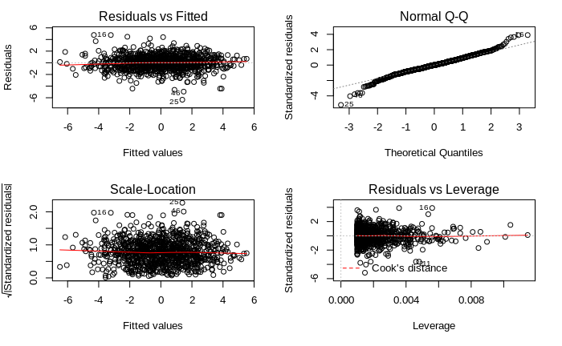

```r
plot(fit)
```

```r
confint(fit)
```

```
                  2.5 %     97.5 %
(Intercept) -0.07616982 0.07616982
x            1.85958669 2.00628963
```

Before we dive into corrections, let’s first examine what’s actually going on.

#### Noise Layer vs Signal Layer

When we add mismatched data to our sample, we’re effectively layering on a random noise model (if we assume the false positives happen at random) which follows $y_i = \epsilon', \epsilon'\sim N(0,5)$ which doesn’t vary with $x$. Below we’ll plot the correct matches in grey, and the incorrect ones in green. The population trend is in red, while our fitted trend is in blue. The dotted green line represends the trend of the mismatched data. Expectedly, it’s slope is near 0.

```r
plot(s[s$match==1,1], s[s$match==1,2], pch= 20, col = 'gray', xlab = 'x', ylab = 'y', main = 'Plot of Correct and Incorrect Matches')
points(s[s$match==0,1], s[s$match==0,2], col = 'green', pch = 20)
```

```r
noise_fit = lm(s[s$match==0,2]~ s[s$match==0,1])
abline(b0, b1, col = 'red')
abline(noise_fit$coefficients[1],noise_fit$coefficients[2], col = 'green', lty=2)
```

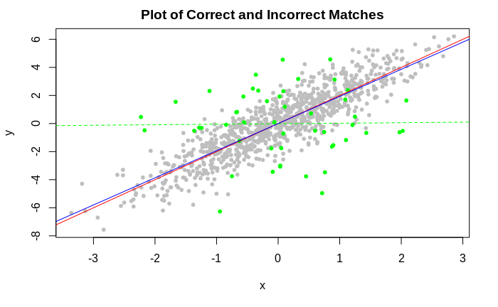

```r
abline(b0_hat,b1_hat, col = 'blue')
```

### Bias

This noise has the effect of dampening the real signal, and leads to a bias where the coefficients are smaller in absolute value than they should be. You can think of this visually as the the green line rotating blue line from where it should be (the red line. This is also why centering all the variables helps), similar to how influential points can move the fitted line.

```r
plot(x = df$x, y = df$y, pch = 20, cex = .2, xlab = 'x', ylab = 'y', main = 'Results of 1000 Simulations')
simulations = sapply(seq(1:1000), function(x){
  s = get_sample(df, precision, n)
  fit = lm(y~x, s)
  b0_hat = fit$coefficients[1]
  b1_hat = fit$coefficients[2]
  abline(fit, col = rgb(red = 0, green = 0, blue = 0.5, alpha = 0.03))
  return(c(b0_hat,b1_hat))

})
```

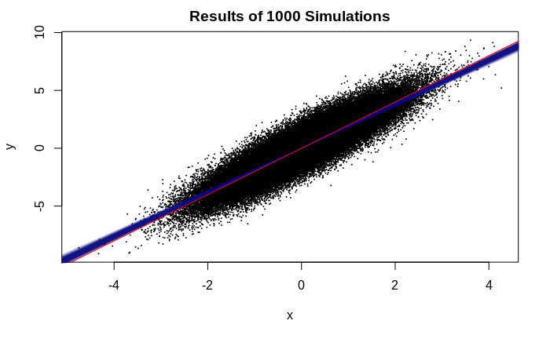

```r
abline(b0, b1, col = 'red')
```

```r
c(quantile(simulations[2,],.025),avg = mean(simulations[2,]),quantile(simulations[2,],.975))
```

```
    2.5%      avg    97.5%
1.823243 1.905018 1.980819
```

Looking at the results, we see that the average $\hat \beta_1$ was 1.9050183, and majority of runs (991) were below the true parameter, indicating a bias in our estimator.

This comes as no surprise given we’ve clearly adding values into our data which don’t follow the true model. Since the number of mismatched records scales linearly with sample size, the bias remains constant no matter the sample size.

### Correcting the Issue

A biased estimator naturally leads to trying to determine what the bias is. We’ll consider two scenarios, one where the number of false positives is unknown, and one where it isn’t.

#### Unknown Precision

A much more likely scenario is that the precision is unknown, in which case the problem is like an outlier/influential point problems. Real outliers are hard to distinguish from false positives, and it is difficult to conduct any investigation into potential outliers, but that’s the price you pay when linking data. We’ll try a few standard approaches to this.

##### Cook’s Distance

Here we’ll use Cook’s distance to try to remove influential points. If we have some prior knowledge of the approximate precision, we can expect to remove a few dozen points. This method won’t capture all the false positives since some will surely look in line with the trend, and therefore we will still have some bias. One possible approach, at least in this controlled example, could be to use the cutoff which yields the largest coefficient. Below we show the resulting estimates using various cutoffs (by removing fixed numbers of values instead of values over a threshold for simplicity), as well as the simulation results for the “best” cutoff. Using this method, we’re much closer to the true value than before, and our confidence intervals are capturing it as well.

```r
cook = function(cutoff) {
  cooks_simulations = sapply(seq(1:100), function(x){
    s = get_sample(df, precision, n)
    initial_fit = lm(y~x, s)
    s_cook = s[cooks.distance(initial_fit)<=sort(cooks.distance(initial_fit))[cutoff],]
    fit = lm(y~x, s_cook)
    b0_hat = fit$coefficients[1]
    b1_hat = fit$coefficients[2]
    return(c(b0_hat,b1_hat, confint(fit)[2,]))
  })
  return(c(
    quantile(cooks_simulations[2,],.025),
    avg = mean(cooks_simulations[2,]),
    quantile(cooks_simulations[2,],.975),
    mean(cooks_simulations[3,]),
    mean(cooks_simulations[4,])))
}
estimates = sapply(seq(900,1000,10), cook)
colnames(estimates) =seq(900,1000,10)
estimates
```

```
           900      910      920      930      940      950      960      970      980      990     1000
2.5%  1.878422 1.895342 1.875108 1.889104 1.881743 1.894151 1.915409 1.884152 1.906411 1.898218 1.831118
avg   1.947491 1.948902 1.956382 1.960364 1.952488 1.963135 1.972450 1.965935 1.976804 1.963497 1.905472
97.5% 2.021075 2.018345 2.021411 2.033687 2.032276 2.022022 2.038669 2.027768 2.040722 2.028842 1.986818
      1.885743 1.886557 1.893695 1.897337 1.888741 1.898688 1.907437 1.900597 1.910539 1.895221 1.831879
      2.009240 2.011247 2.019068 2.023391 2.016235 2.027582 2.037463 2.031274 2.043068 2.031774 1.979065
```

```r
plot(x = df$x, y = df$y, pch = 20, cex = .2, xlab = 'x', ylab = 'y', main = "Results of 1000 Simulations with Cook's distance correction")
cooks_simulations = sapply(seq(1:1000), function(x){
  s = get_sample(df, precision, n)
  initial_fit = lm(y~x, s)
  s_cook = s[cooks.distance(initial_fit)<=sort(cooks.distance(initial_fit))[980],]
  fit = lm(y~x, s_cook)
  b0_hat = fit$coefficients[1]
  b1_hat = fit$coefficients[2]
  abline(fit, col = rgb(red = 0, green = 0, blue = 0.5, alpha = 0.03))
  return(c(b0_hat,b1_hat))
})
```

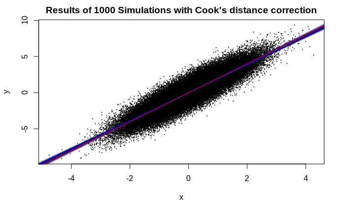

```r
abline(b0, b1, col = 'red')
```

##### Robust Regression

Next we’ll use robust regression, implemented as `rlm()` in R (versus ordinary least squares used in `lm()`). Since we’re still using all the data, we’re still expecting to generally underestimate the mean. Similar to Cook’s distance, we’re doing much better than OLS and with confidence intervals beginning to capture the true parameter. A similar approach would be weighted least squares. My suspicion is that these approaches are slightly worse than the previous approach because they maintain all false positives and try to minimize their effect, as opposed to attemping to remove the false positives completely. In practice, I’m not sure there’s a meaningful difference.

```r
plot(x = df$x, y = df$y, pch = 20, cex = .2, xlab = 'x', ylab = 'y', main = 'Results of 1000 Simulations with Robust Regression')
robust_simulations = sapply(seq(1:1000), function(x){
  s = get_sample(df, precision, n)
  fit = rlm(y~x, s)
  b0_hat = fit$coefficients[1]
  b1_hat = fit$coefficients[2]
  abline(fit, col = rgb(red = 0, green = 0, blue = 0.5, alpha = 0.03))
  return(c(b0_hat,b1_hat))

})
```

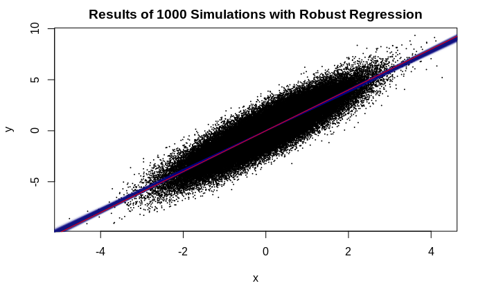

```r
abline(b0, b1, col = 'red')
```

```r
c(quantile(robust_simulations[2,],.025),avg = mean(robust_simulations[2,]) ,quantile(robust_simulations[2,],.975))
```

```
    2.5%      avg    97.5%
1.892992 1.958830 2.027997
```

#### Known Precision

If, somehow, the precision is known and so the number of false positives can be determined, there is a simple correction that can be done. By dividing the estimates by the precision, we get the right answer. This intuitively makes sense because we’ve “dampened” the true signal with the random noise, and if we know how severe the noise is, we can scale the signal to it’s real value. This comes at the expense of a wider confidence interval, as the standard errors are also divided by 0.95.

```r
c(quantile(simulations[2,]/precision,.025), avg=mean(simulations[2,])/precision,quantile(simulations[2,]/precision,.975))
```

```
    2.5%      avg    97.5%
1.919203 2.005282 2.085072
```

#### Theory and Analysis

#### High Dimensions

#### Quadratic Example

#### Upside - small effects, not wrong effects

#### Effective Sample Size